# Temperature analyses

Laura Segura Hernández

2022-08-06

# 1 Description

In this script I achieve the following:

1. Obtain the final temperature values to then estimate the oxygen consumed by pseudoscorpions in the thermolimit respirometry
   - I start by reading and structuring the temperature records from both the external HOBO loggers used in the thermolimit respirometry trials. Then I also take the temperatures recorded by hand by both, the thermocouple external sensor, and the recorded temperature by the actual thermal block where the trials took place.And I merge it into a single file to explore the relationship between the different temperature sensors.
   - I then choose the best/more reliable one to use the most accurate temperature data for the oxygen estimation (separate script).
   - I then used the equation of the line to be able to predict the temperature in the thermal block (the chosen temperature to use) based of the loggers temperatures (for which I have more constant data collected).
   - I use this equation to correct the temperatures of all the trials for the thermolimit respirometry and so be able to further estimate oxygen consumption (separate script)
2. Estimate the heat rigor or CTmax for the pseudoscorpions exposed to the same temperature treatment used in the thermolimit respirometry trials, but scored through behavioral observations (i.e. the point in time and temperature at which they stop moving).
   - For this I used similar steps to the described above.

# 2 Libraries

```r
library(data.table)
library(tidyr)
library(dplyr)
library(lubridate)
library(ggplot2)
library(fuzzyjoin)
library(forcats)
```

# 3 Organizing data

## 3.1 Reading files

```r
cnames<-c("#", "datetime", "temp1", "temp2", "detached", "attached", "connected", "end","x")

t1.3<-read.csv("Data/Temperature/Thermal_block_trials1-3_1.csv", skip=2, header=F, col.names=cnames)

t4.7<-read.csv("Data/Temperature/Thermal_block_trials_4-7_0.csv", skip=2, header=F, col.names=cnames)

t8.13<-read.csv("Data/Temperature/Thermal_block_trials_8-13.csv", skip=2, header=F,col.names=cnames)

head(t1.3)
```

|  | X. | datetime | temp1 | temp2 | detached | attached | connected | end | x |
| --- | --- | --- | --- | --- | --- | --- | --- | --- | --- |
| 1 | 1 | 06/21/22 08:33:37 AM | 24.098 | 24.050 |  |  |  |  |  |
| 2 | 2 | 06/21/22 08:34:37 AM | 24.098 | 24.050 |  |  |  |  |  |
| 3 | 3 | 06/21/22 08:34:45 AM | NA | NA | Logged |  |  |  |  |
| 4 | 4 | 06/21/22 08:35:37 AM | 24.122 | 24.098 |  |  |  |  |  |
| 5 | 5 | 06/21/22 08:36:37 AM | 24.195 | 24.146 |  |  |  |  |  |
| 6 | 6 | 06/21/22 08:37:37 AM | 24.195 | 24.146 |  |  |  |  |  |

## 3.2 Organizing and adding data

```r
t1.3<- t1.3 %>%
  na.omit() %>% #removing NAs
  select(1:4) %>% #removing non-relevant columns
  mutate(datetime=as_datetime(datetime, format="%m/%d/%y %I:%M:%S %p")) %>% #converting the datetime column from character into a datetime format
  separate(datetime, c("date", "time"), remove=FALSE, sep=" ") %>% #separating date and time into two columns
  mutate(date=ymd(date), #formatting date
         tempav=rowMeans(.[,5:6]), #calculating averages for the two temperature sensors
        trial=case_when(datetime >= ymd_hms("2022-06-21 09:53:00") &
                               datetime <= ymd_hms("2022-06-21 10:50:00")~1, #Assigning trial 1
                        datetime >= ymd_hms("2022-06-21 14:58:00") &
                               datetime <= ymd_hms("2022-06-21 17:08:00")~2,#Assigning trial 2
                        datetime >= ymd_hms("2022-06-21 18:19:00") &
                               datetime <= ymd_hms("2022-06-21 20:28:00")~3,#Assigning trial 3

                        TRUE~0))

t4.7<- t4.7 %>%
  na.omit() %>% #removing NAs
  select(1:4) %>% #removing non-relevant columns
  mutate(datetime=as_datetime(datetime, format="%m/%d/%y %I:%M:%S %p")) %>% #converting the datetime column from character into a datetime format
  separate(datetime, c("date", "time"), remove=FALSE, sep=" ") %>% #separating date and time into two columns
  mutate(date=ymd(date), #formatting date
         tempav=rowMeans(.[,5:6]), #calculating averages for the two temperature sensors
        trial=case_when(datetime >= ymd_hms("2022-06-22 11:07:00") &
                               datetime <= ymd_hms("2022-06-22 13:19:00")~4, #Assigning trial 4
                        datetime >= ymd_hms("2022-06-22 14:10:00") &
                               datetime <= ymd_hms("2022-06-22 16:24:00")~5,#Assigning trial 5
                        datetime >= ymd_hms("2022-06-22 17:26:00") &
                               datetime <= ymd_hms("2022-06-22 19:50:00")~6,#Assigning trial 6
                        datetime >= ymd_hms("2022-06-22 20:23:00") &
                               datetime <= ymd_hms("2022-06-22 22:29:00")~7,#Assigning trial 7
                        TRUE~0))


t8.13<- t8.13 %>%
  na.omit() %>% #removing NAs
  select(1:4) %>% #removing non-relevant columns
  mutate(datetime=as_datetime(datetime, format="%m/%d/%y %I:%M:%S %p")) %>% #converting the datetime column from character into a datetime format
  separate(datetime, c("date", "time"), remove=FALSE, sep=" ") %>% #separating date and time into two columns
  mutate(date=ymd(date), #formatting date
          tempav=rowMeans(.[,5:6]), #calculating averages for the two temperature sensors
        trial=case_when(datetime >= ymd_hms("2022-06-23 09:37:00") &
                               datetime <= ymd_hms("2022-06-23 11:48:00")~8, #Assigning trial 8
                        datetime >= ymd_hms("2022-06-23 12:39:00") &
                               datetime <= ymd_hms("2022-06-23 14:56:00")~9,#Assigning trial 9
                        datetime >= ymd_hms("2022-06-23 15:38:00") &
                               datetime <= ymd_hms("2022-06-23 17:55:00")~10,#Assigning trial 10
                        datetime >= ymd_hms("2022-06-23 18:33:00") &
                               datetime <= ymd_hms("2022-06-23 20:50:00")~11,#Assigning trial 11
                        datetime >= ymd_hms("2022-06-23 21:43:00") &
                               datetime <= ymd_hms("2022-06-24 00:00:00")~12,#Assigning trial 12
                        datetime >= ymd_hms("2022-06-24 00:44:00") &
                               datetime <= ymd_hms("2022-06-24 03:01:00")~13,#Assigning trial 13
                        TRUE~0))

head(t1.3)
```

|  | X. | datetime | date | time | temp1 | temp2 | tempav | trial |
| --- | --- | --- | --- | --- | --- | --- | --- | --- |
| 1 | 1 | 2022-06-21 08:33:37 | 2022-06-21 | 08:33:37 | 24.098 | 24.050 | 24.0740 | 0 |
| 2 | 2 | 2022-06-21 08:34:37 | 2022-06-21 | 08:34:37 | 24.098 | 24.050 | 24.0740 | 0 |
| 4 | 4 | 2022-06-21 08:35:37 | 2022-06-21 | 08:35:37 | 24.122 | 24.098 | 24.1100 | 0 |
| 5 | 5 | 2022-06-21 08:36:37 | 2022-06-21 | 08:36:37 | 24.195 | 24.146 | 24.1705 | 0 |
| 6 | 6 | 2022-06-21 08:37:37 | 2022-06-21 | 08:37:37 | 24.195 | 24.146 | 24.1705 | 0 |
| 7 | 7 | 2022-06-21 08:38:37 | 2022-06-21 | 08:38:37 | 24.195 | 24.146 | 24.1705 | 0 |

## 3.3 Merging dataframes into a single one

```r
loggers<-bind_rows(t1.3,t4.7, t8.13) %>%
  mutate(datetime2=round_date(datetime, unit="minute")) #creating a coluns of datetime rounded by minutes to facilitate merging later

head(loggers)
```

|  | X. | datetime | date | time | temp1 | temp2 | tempav | trial | datetime2 |
| --- | --- | --- | --- | --- | --- | --- | --- | --- | --- |
| 1 | 1 | 2022-06-21 08:33:37 | 2022-06-21 | 08:33:37 | 24.098 | 24.050 | 24.0740 | 0 | 2022-06-21 08:34:00 |
| 2 | 2 | 2022-06-21 08:34:37 | 2022-06-21 | 08:34:37 | 24.098 | 24.050 | 24.0740 | 0 | 2022-06-21 08:35:00 |
| 3 | 4 | 2022-06-21 08:35:37 | 2022-06-21 | 08:35:37 | 24.122 | 24.098 | 24.1100 | 0 | 2022-06-21 08:36:00 |
| 4 | 5 | 2022-06-21 08:36:37 | 2022-06-21 | 08:36:37 | 24.195 | 24.146 | 24.1705 | 0 | 2022-06-21 08:37:00 |
| 5 | 6 | 2022-06-21 08:37:37 | 2022-06-21 | 08:37:37 | 24.195 | 24.146 | 24.1705 | 0 | 2022-06-21 08:38:00 |
| 6 | 7 | 2022-06-21 08:38:37 | 2022-06-21 | 08:38:37 | 24.195 | 24.146 | 24.1705 | 0 | 2022-06-21 08:39:00 |

## 3.4 Creating dataframe for thermocouple variables

```r
# Trial 4
trial<-rep(4)
datetime<-c("2022-06-22 11:12:00", "2022-06-22 11:16:00","2022-06-22 11:48:00","2022-06-22 12:30:00","2022-06-22 12:55:00","2022-06-22 13:19:00")
tempblock<-c(30,30,38,48,55,57)
tempcouple<-c(28.3,28.3,37.1,47.1,53.7,55.5)

t4<-data.frame(trial, datetime,tempblock, tempcouple)
t4<-t4%>%
  mutate(datetime2=ymd_hms(datetime))


# Trial 5
trial<-rep(5)
datetime<-c("2022-06-22 14:14:00", "2022-06-22 14:34:00","2022-06-22 15:11:00","2022-06-22 15:45:00","2022-06-22 16:07:00","2022-06-22 16:18:00")
tempblock<-c(30,33,42,51,57,57)
tempcouple<-c(28.2,32.1,40.9,49.5,55.6,55.3)

t5<-data.frame(trial, datetime, tempblock,tempcouple)
t5<-t5%>%
  mutate(datetime2=ymd_hms(datetime))

# Trial 6
trial<-rep(6)
datetime<-c("2022-06-22 17:34:00", "2022-06-22 17:57:00","2022-06-22 18:27:00","2022-06-22 18:47:00","2022-06-22 19:07:00","2022-06-22 19:29:00", "2022-06-22 19:31:00", "2022-06-22 19:50:00")
tempblock<-c(30,33,40,45,50,56,56,57)
tempcouple<-c(28.1,32.2,38.9,43.7,48.6,54.7,54.7,55.5)

t6<-data.frame(trial, datetime,tempblock, tempcouple)
t6<-t6%>%
  mutate(datetime2=ymd_hms(datetime))

# Trial 7
trial<-rep(7)
datetime<-c("2022-06-22 20:25:00", "2022-06-22 21:37:00","2022-06-22 22:08:00","2022-06-22 22:18:00","2022-06-22 22:28:00")
tempblock<-c(30,46,54,56,57)
tempcouple<-c(27.2,44.9,52.8,54.7,55.6)

t7<-data.frame(trial, datetime,tempblock, tempcouple)
t7<-t7%>%
  mutate(datetime2=ymd_hms(datetime))

# Trial 8
trial<-rep(8)
datetime<-c("2022-06-23 09:39:00", "2022-06-23 09:45:00","2022-06-23 09:55:00","2022-06-23 10:08:00","2022-06-23 10:15:00","2022-06-23 10:25:00","2022-06-23 10:36:00","2022-06-23 10:46:00","2022-06-23 11:06:00","2022-06-23 11:16:00","2022-06-23 11:26:00","2022-06-23 11:30:00")
tempblock<-c(30,30,32,35,37,40,43,45,50,53,55,56)
tempcouple<-c(27.6,28.1,31.3,34.2,36.3,39.3,42.3,44.2,49.0,52.0,53.8,55)

t8<-data.frame(trial, datetime,tempblock, tempcouple)
t8<-t8%>%
  mutate(datetime2=ymd_hms(datetime))

# Trial 9
trial<-rep(9)
datetime<-c("2022-06-23 12:50:00", "2022-06-23 13:10:00","2022-06-23 14:01:00","2022-06-23 14:37:00")
tempblock<-c(30,34,47,56)
tempcouple<-c(29.0,33.2,46.2,55)

t9<-data.frame(trial, datetime,tempblock, tempcouple)
t9<-t9%>%
  mutate(datetime2=ymd_hms(datetime))

# Trial 10
trial<-rep(10)
datetime<-c("2022-06-23 15:48:00", "2022-06-23 16:08:00","2022-06-23 17:08:00","2022-06-23 17:33:00","2022-06-23 17:36:00","2022-06-23 17:56:00")
tempblock<-c(30,34,49,56,56,57)
tempcouple<-c(29.2,33.5,48.2,55.0,55,55)

t10<-data.frame(trial, datetime,tempblock, tempcouple)
t10<-t10%>%
  mutate(datetime2=ymd_hms(datetime))

# Trial 11
trial<-rep(11)
datetime<-c("2022-06-23 18:37:00", "2022-06-23 18:43:00","2022-06-23 20:00:00","2022-06-23 20:31:00","2022-06-23 20:42:00")
tempblock<-c(30,30,49,56,57)
tempcouple<-c(29,29.3,48.2,55.1,56)

t11<-data.frame(trial, datetime,tempblock, tempcouple)
t11<-t11%>%
  mutate(datetime2=ymd_hms(datetime))

# Trial 12
trial<-rep(12)
datetime<-c("2022-06-23 21:53:00", "2022-06-23 23:40:00","2022-06-23 23:41:00")
tempblock<-c(30,56,56)
tempcouple<-c(28.6,54.8,54.9)

t12<-data.frame(trial, datetime,tempblock, tempcouple)
t12<-t12%>%
  mutate(datetime2=ymd_hms(datetime))

# Trial 13
trial<-rep(13)
datetime<-c("2022-06-24 00:52:00", "2022-06-24 00:55:00","2022-06-24 01:51:00","2022-06-24 02:25:00","2022-06-24 02:42:00","2022-06-24 02:57:00")
tempblock<-c(30,30,43,52,56,57)
tempcouple<-c(28.5,28.9,42.4,50.8,54.9,56.1)

t13<-data.frame(trial, datetime,tempblock, tempcouple)
t13<-t13%>%
  mutate(datetime2=ymd_hms(datetime))


#Merging all into a single frame
couples<-bind_rows(t4,t5,t6,t7,t8,t9,t10,t11,t12,t13)

head(couples)
```

|  | trial | datetime | tempblock | tempcouple | datetime2 |
| --- | --- | --- | --- | --- | --- |
| 1 | 4 | 2022-06-22 11:12:00 | 30 | 28.3 | 2022-06-22 11:12:00 |
| 2 | 4 | 2022-06-22 11:16:00 | 30 | 28.3 | 2022-06-22 11:16:00 |
| 3 | 4 | 2022-06-22 11:48:00 | 38 | 37.1 | 2022-06-22 11:48:00 |
| 4 | 4 | 2022-06-22 12:30:00 | 48 | 47.1 | 2022-06-22 12:30:00 |
| 5 | 4 | 2022-06-22 12:55:00 | 55 | 53.7 | 2022-06-22 12:55:00 |
| 6 | 4 | 2022-06-22 13:19:00 | 57 | 55.5 | 2022-06-22 13:19:00 |

## 3.5 Merging loggers and thermocouple data into a single dataframe

```r
all<-full_join(loggers, couples, by=c("datetime2","trial"), suffix=c("", ".cb"))
head(all)
```

|  | X. | datetime | date | time | temp1 | temp2 | tempav | trial | datetime2 | datetime.cb | tempblock | tempcouple |
| --- | --- | --- | --- | --- | --- | --- | --- | --- | --- | --- | --- | --- |
| 1 | 1 | 2022-06-21 08:33:37 | 2022-06-21 | 08:33:37 | 24.098 | 24.050 | 24.0740 | 0 | 2022-06-21 08:34:00 | NA | NA | NA |
| 2 | 2 | 2022-06-21 08:34:37 | 2022-06-21 | 08:34:37 | 24.098 | 24.050 | 24.0740 | 0 | 2022-06-21 08:35:00 | NA | NA | NA |
| 3 | 4 | 2022-06-21 08:35:37 | 2022-06-21 | 08:35:37 | 24.122 | 24.098 | 24.1100 | 0 | 2022-06-21 08:36:00 | NA | NA | NA |
| 4 | 5 | 2022-06-21 08:36:37 | 2022-06-21 | 08:36:37 | 24.195 | 24.146 | 24.1705 | 0 | 2022-06-21 08:37:00 | NA | NA | NA |
| 5 | 6 | 2022-06-21 08:37:37 | 2022-06-21 | 08:37:37 | 24.195 | 24.146 | 24.1705 | 0 | 2022-06-21 08:38:00 | NA | NA | NA |
| 6 | 7 | 2022-06-21 08:38:37 | 2022-06-21 | 08:38:37 | 24.195 | 24.146 | 24.1705 | 0 | 2022-06-21 08:39:00 | NA | NA | NA |

# 4 Exploring data

## 4.1 Looking at the differences between loggers, thermalblock and thermocouple

```r
diffs<-all %>%
  mutate(diffblock=tempblock-tempav,
         diffcouple=tempcouple-tempav) %>%
  na.omit()

head(diffs)
```

|  | X. | datetime | date | time | temp1 | temp2 | tempav | trial | datetime2 | datetime.cb | tempblock | tempcouple | diffblock | diffcouple |
| --- | --- | --- | --- | --- | --- | --- | --- | --- | --- | --- | --- | --- | --- | --- |
| 860 | 128 | 2022-06-22 11:11:44 | 2022-06-22 | 11:11:44 | 29.365 | 29.365 | 29.3650 | 4 | 2022-06-22 11:12:00 | 2022-06-22 11:12:00 | 30 | 28.3 | 0.6350 | -1.0650 |
| 861 | 129 | 2022-06-22 11:12:14 | 2022-06-22 | 11:12:14 | 29.315 | 29.340 | 29.3275 | 4 | 2022-06-22 11:12:00 | 2022-06-22 11:12:00 | 30 | 28.3 | 0.6725 | -1.0275 |
| 868 | 136 | 2022-06-22 11:15:44 | 2022-06-22 | 11:15:44 | 29.540 | 29.590 | 29.5650 | 4 | 2022-06-22 11:16:00 | 2022-06-22 11:16:00 | 30 | 28.3 | 0.4350 | -1.2650 |
| 869 | 137 | 2022-06-22 11:16:14 | 2022-06-22 | 11:16:14 | 29.540 | 29.565 | 29.5525 | 4 | 2022-06-22 11:16:00 | 2022-06-22 11:16:00 | 30 | 28.3 | 0.4475 | -1.2525 |
| 932 | 200 | 2022-06-22 11:47:44 | 2022-06-22 | 11:47:44 | 36.552 | 36.905 | 36.7285 | 4 | 2022-06-22 11:48:00 | 2022-06-22 11:48:00 | 38 | 37.1 | 1.2715 | 0.3715 |
| 933 | 201 | 2022-06-22 11:48:14 | 2022-06-22 | 11:48:14 | 36.742 | 36.878 | 36.8100 | 4 | 2022-06-22 11:48:00 | 2022-06-22 11:48:00 | 38 | 37.1 | 1.1900 | 0.2900 |

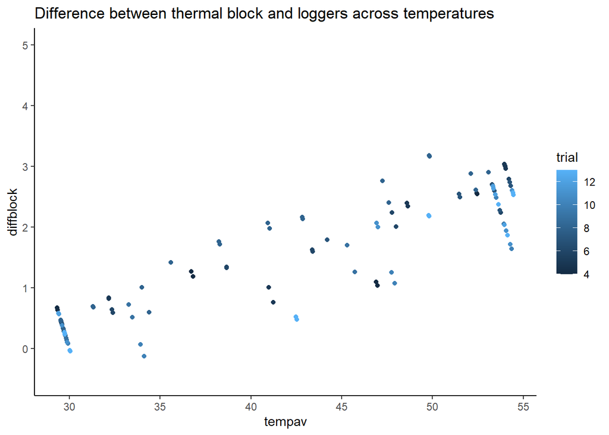

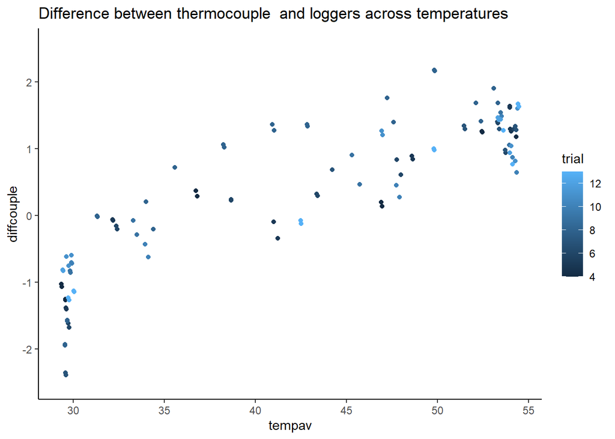

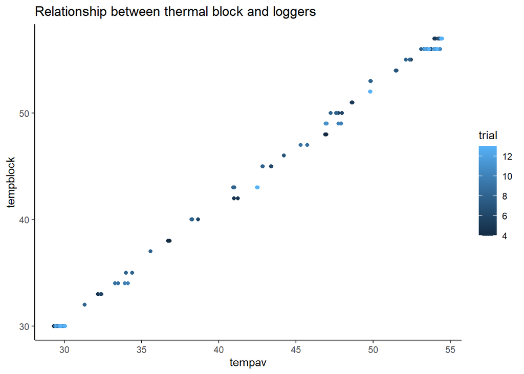

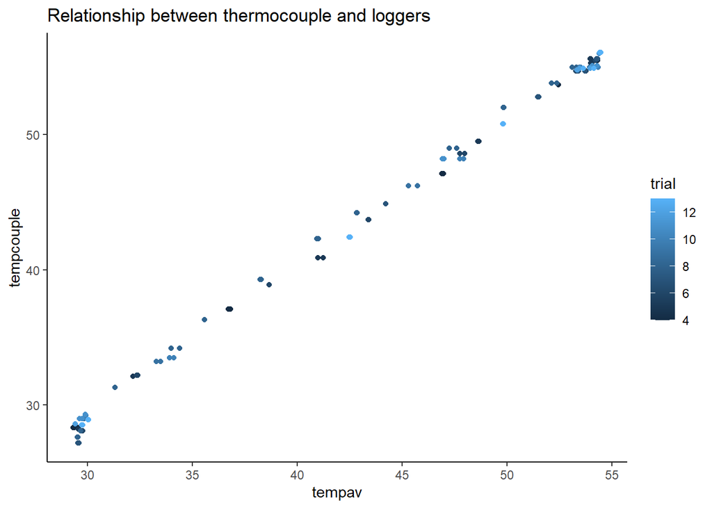

```r
ggplot(diffs, aes(x=tempav,y=diffblock, color=trial))+
  geom_point()+ylim(-0.5,5) +theme_classic()+ggtitle("Difference between thermal block and loggers across temperatures")

ggplot(diffs, aes(x=tempav,y=diffcouple, color=trial))+
  geom_point()+ylim(-2.5,2.55)+theme_classic()+ggtitle("Difference between thermocouple  and loggers across temperatures")

ggplot(diffs, aes(x=tempav,y=tempblock, color=trial))+
  geom_point()+theme_classic()+ggtitle("Relationship between thermal block and loggers")

ggplot(diffs, aes(x=tempav,y=tempcouple, color=trial))+
  geom_point()+theme_classic()+ggtitle("Relationship between thermocouple and loggers")
```

> I think using the block temperatures would be better to correct the logger temperatures because:
1. The block sensor is always in the same position, but the thermocouple wire might have been placed on different spots or moved in between trials
2. The thermal block was done to keep track of specific temperatures to do PCRs, etc, therefore, it should be fairly accurate on how much the samples were heat up

#Correcting data

## 4.2 Estimating the slope to correct the logger temperatures

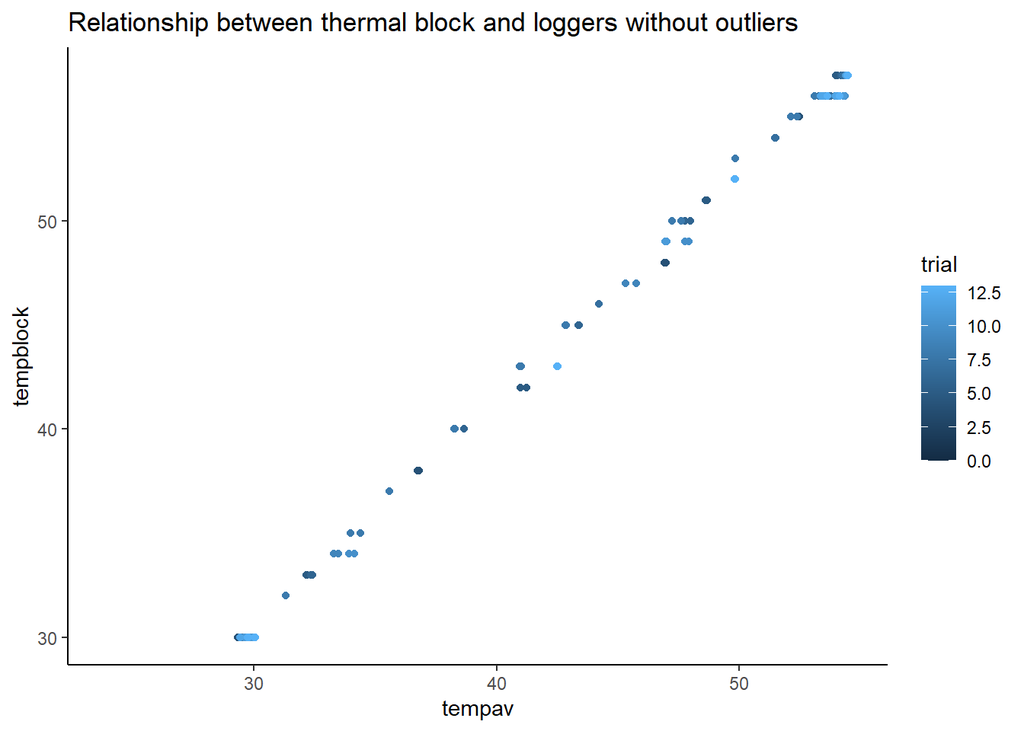

```r
#Removing the extreme values
all2<-all%>%
  filter(X.!=1200) %>%
  filter(X.!=1201)


ggplot(all2, aes(x=tempav,y=tempblock, color=trial))+
  geom_point()+theme_classic()+ggtitle("Relationship between thermal block and loggers without outliers")
```

```r
lm1<-lm(tempblock~tempav, data=all2)
lm1
```

```
##
## Call:
## lm(formula = tempblock ~ tempav, data = all2)
##
## Coefficients:
## (Intercept)       tempav
##      -2.324        1.091
```

```r
slope<-lm1$coefficients[2]
int<-lm1$coefficients[1]
```

> As it is a linear relationship, I can now correct the loggers temps (x) to get the block temperature by using the formula:

$$\begin{align*}
y=m&x+b \\
o&r \\
block temperature = slope * l&ogger temperature + intercept \\
\end{align*}$$

## 4.3 Correcting the temperatures for each trial

```r
# Removing trial 0 and correcting all other temperatures
all_corr<-all%>%
  filter(trial!=0) %>%
  mutate(tempcorr=(slope*tempav)+int)

head(all_corr)
```

|  | X. | datetime | date | time | temp1 | temp2 | tempav | trial | datetime2 | datetime.cb | tempblock | tempcouple | tempcorr |
| --- | --- | --- | --- | --- | --- | --- | --- | --- | --- | --- | --- | --- | --- |
| 1 | 82 | 2022-06-21 09:53:37 | 2022-06-21 | 09:53:37 | 25.089 | 25.453 | 25.2710 | 1 | 2022-06-21 09:54:00 | NA | NA | NA | 25.23569 |
| 2 | 83 | 2022-06-21 09:54:37 | 2022-06-21 | 09:54:37 | 26.304 | 25.963 | 26.1335 | 1 | 2022-06-21 09:55:00 | NA | NA | NA | 26.17632 |
| 3 | 84 | 2022-06-21 09:55:37 | 2022-06-21 | 09:55:37 | 27.949 | 26.720 | 27.3345 | 1 | 2022-06-21 09:56:00 | NA | NA | NA | 27.48611 |
| 4 | 85 | 2022-06-21 09:56:37 | 2022-06-21 | 09:56:37 | 28.791 | 27.210 | 28.0005 | 1 | 2022-06-21 09:57:00 | NA | NA | NA | 28.21244 |
| 5 | 86 | 2022-06-21 09:57:37 | 2022-06-21 | 09:57:37 | 29.140 | 27.530 | 28.3350 | 1 | 2022-06-21 09:58:00 | NA | NA | NA | 28.57724 |
| 6 | 87 | 2022-06-21 09:58:37 | 2022-06-21 | 09:58:37 | 29.340 | 27.702 | 28.5210 | 1 | 2022-06-21 09:59:00 | NA | NA | NA | 28.78009 |

## 4.4 Estimating temperature slope for each trial

### 4.4.1 Without removing bump at the begining of ramp

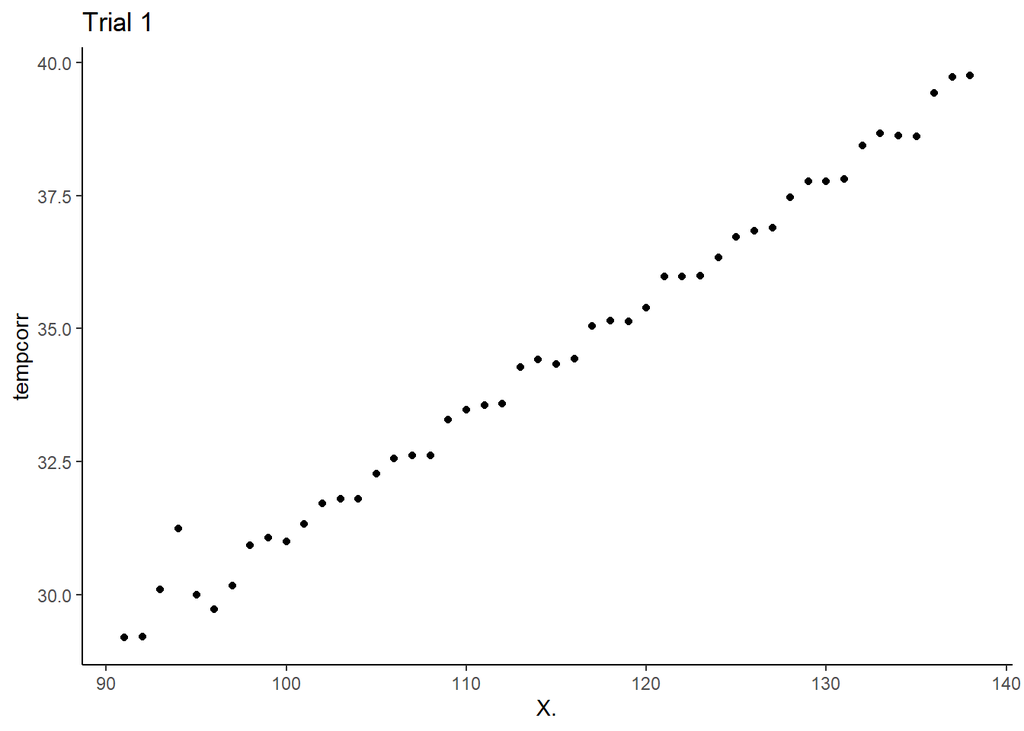

```r
# Trial 1
r1<-all_corr %>%
  filter(trial==1,
         datetime2 >= ymd_hms("2022-06-21 10:03:00") &
                               datetime <= ymd_hms("2022-06-21 10:50:00"))

ggplot(r1, aes(x=X.,y=tempcorr))+
  geom_point()+theme_classic()+ggtitle("Trial 1")
```

```r
lmtemp<-lm(tempcorr~X., data=r1)
sl1<-lmtemp$coefficients[2]
round(sl1, digits=2)
```

```
##   X.
## 0.22
```

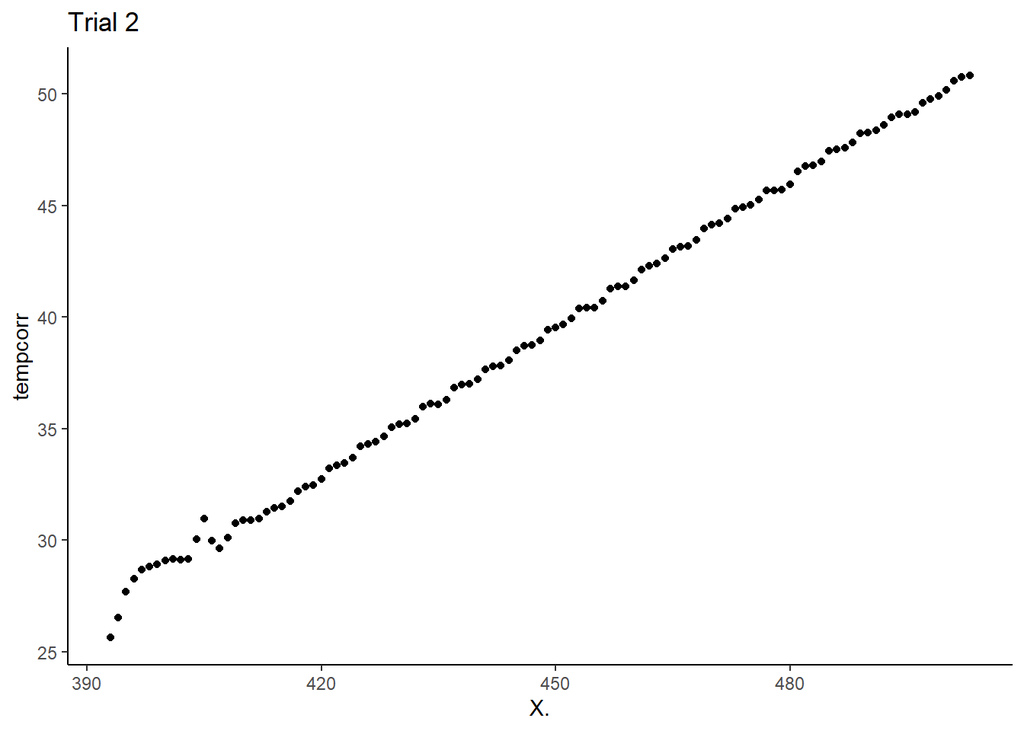

```r
# Trial 2
r2<-all_corr %>%
  filter(trial==2,
         datetime2 >= ymd_hms("2022-06-21 15:02:00") &
                               datetime <= ymd_hms("2022-06-21 16:52:00"))

ggplot(r2, aes(x=X.,y=tempcorr))+
  geom_point()+theme_classic()+ggtitle("Trial 2")
```

```r
lmtemp<-lm(tempcorr~X., data=r2)
sl2<-lmtemp$coefficients[2]
round(sl2, digits=2) #it remains the same independentaly of removing the curve at the begining of the ramp or not
```

```
##   X.
## 0.22
```

```r
sl2
```

```
##        X.
## 0.2177813
```

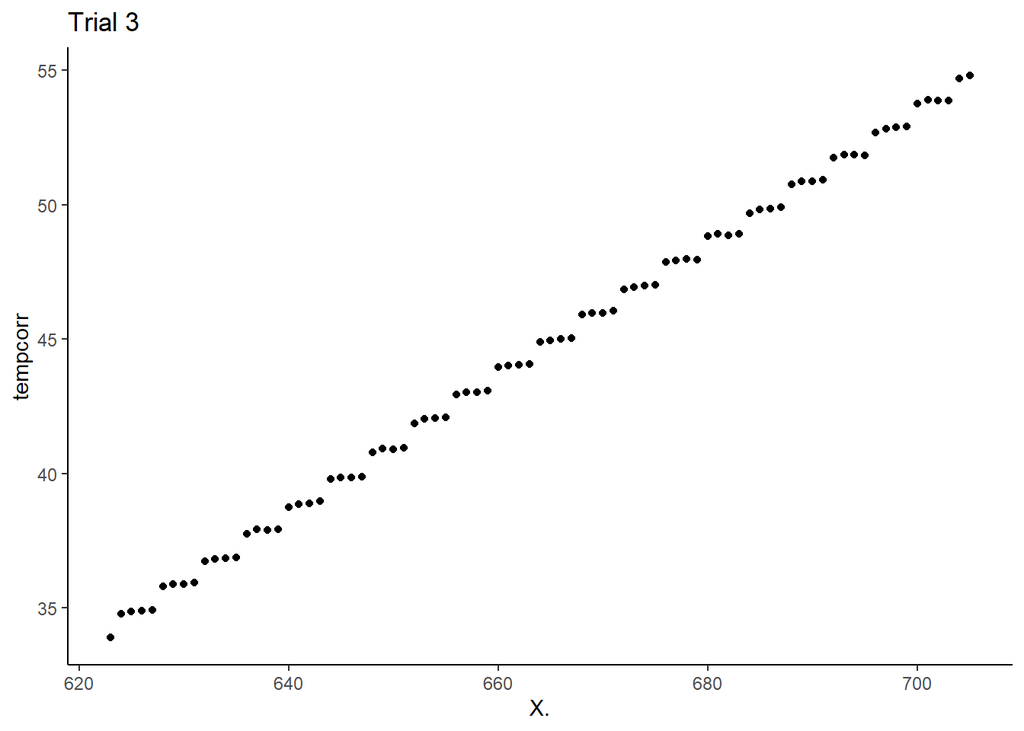

```r
# Trial 3
r3<-all_corr %>%
  filter(trial==3,
         datetime2 >= ymd_hms("2022-06-21 18:49:00") & datetime <= ymd_hms("2022-06-21 20:11:00"))

ggplot(r3, aes(x=X.,y=tempcorr))+
  geom_point()+theme_classic()+ggtitle("Trial 3")
```

```r
lmtemp<-lm(tempcorr~X., data=r3)
sl3<-lmtemp$coefficients[2]
round(sl3, digits=2)
```

```
##   X.
## 0.25
```

```r
sl3
```

```
##        X.
## 0.2499655
```

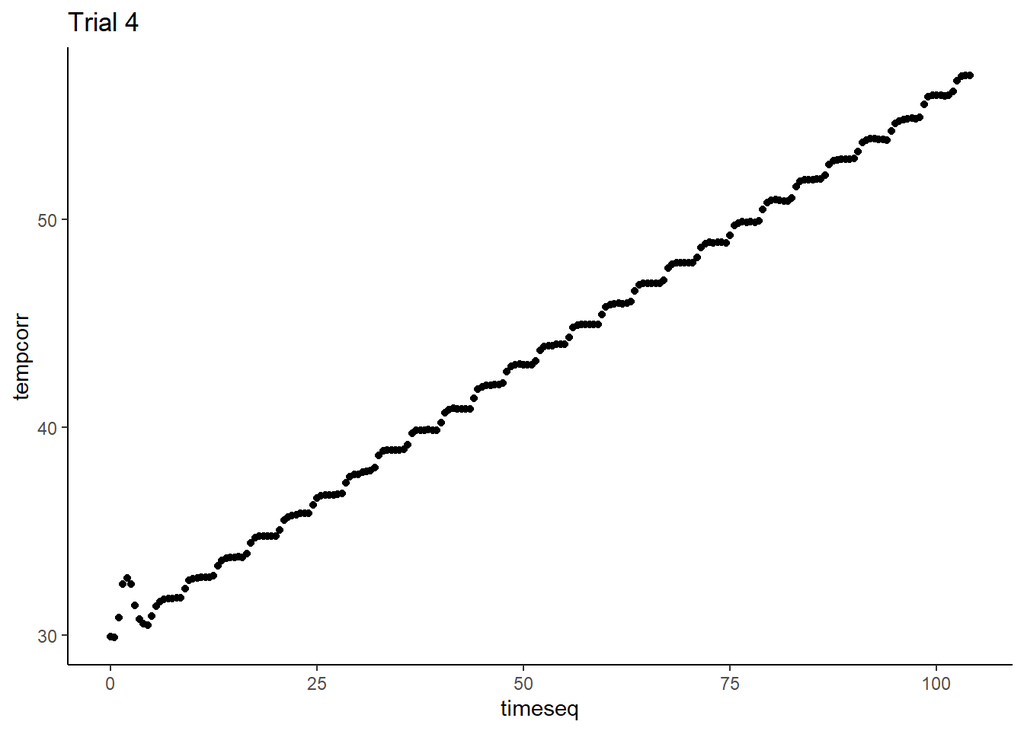

```r
# Trial 4
r4<-all_corr %>%
  filter(trial==4,
         datetime2 >= ymd_hms("2022-06-22 11:18:00") &
                               datetime <= ymd_hms("2022-06-22 13:02:00")) %>%
  mutate(timeseq=seq(from=0, to=104,by=0.5))

ggplot(r4, aes(x=timeseq,y=tempcorr))+
  geom_point()+theme_classic()+ggtitle("Trial 4")
```

```r
lmtemp<-lm(tempcorr~timeseq, data=r4)
sl4<-lmtemp$coefficients[2]
round(sl4, digits=2)
```

```
## timeseq
##    0.26
```

```r
sl4
```

```
##  timeseq
## 0.257621
```

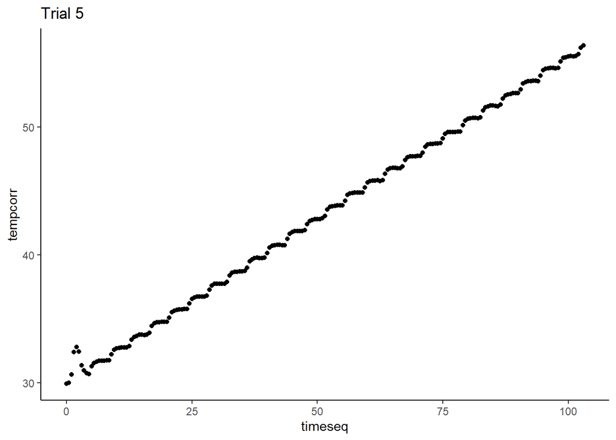

```r
# Trial 5
r5<-all_corr %>%
  filter(trial==5,
         datetime2 >= ymd_hms("2022-06-22 14:23:00") &
                               datetime <= ymd_hms("2022-06-22 16:06:00"))  %>%
  mutate(timeseq=seq(from=0, to=103,by=0.5))

ggplot(r5, aes(x=timeseq,y=tempcorr))+
  geom_point()+theme_classic()+ggtitle("Trial 5")
```

```r
lmtemp<-lm(tempcorr~timeseq, data=r5)
sl5<-lmtemp$coefficients[2]
round(sl5, digits=2)
```

```
## timeseq
##    0.25
```

```r
sl5
```

```
##   timeseq
## 0.2536465
```

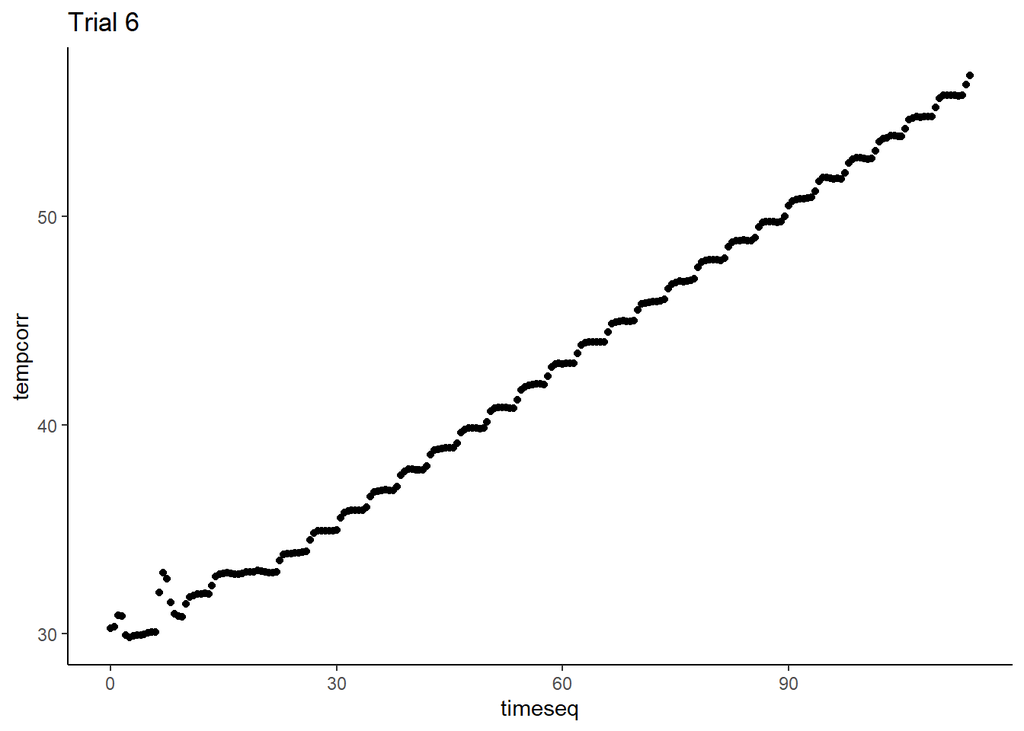

```r
#Trial 6
r6<-all_corr %>%
  filter(trial==6,
         datetime2 >= ymd_hms("2022-06-22 17:38:00") &
                               datetime <= ymd_hms("2022-06-22 19:32:00")) %>%
  mutate(timeseq=seq(from=0, to=114,by=0.5))

ggplot(r6, aes(x=timeseq,y=tempcorr))+
  geom_point()+theme_classic()+ggtitle("Trial 6")
```

```r
lmtemp<-lm(tempcorr~timeseq, data=r6)
sl6<-lmtemp$coefficients[2]
round(sl6, digits=2)
```

```
## timeseq
##    0.24
```

```r
sl6
```

```
##   timeseq
## 0.2406644
```

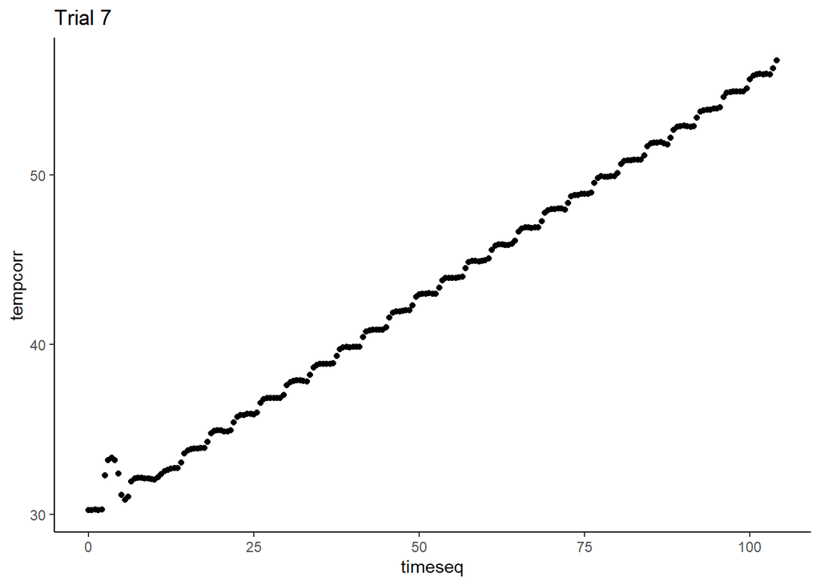

```r
#Trial 7
r7<-all_corr %>%
  filter(trial==7,
         datetime2 >= ymd_hms("2022-06-22 20:35:00") &
                               datetime <= ymd_hms("2022-06-22 22:19:00"))  %>%
  mutate(timeseq=seq(from=0, to=104,by=0.5))

ggplot(r7, aes(x=timeseq,y=tempcorr))+
  geom_point()+theme_classic()+ggtitle("Trial 7")
```

```r
lmtemp<-lm(tempcorr~timeseq, data=r7)
sl7<-lmtemp$coefficients[2]
round(sl7, digits=2)
```

```
## timeseq
##    0.25
```

```r
sl7
```

```
##   timeseq
## 0.2537901
```

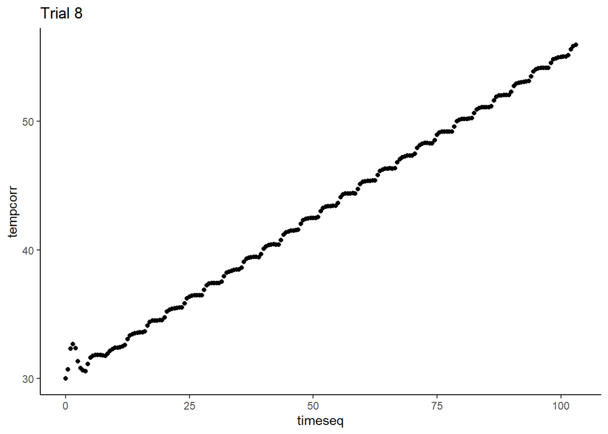

```r
#Trial 8
r8<-all_corr %>%
  filter(trial==8,
         datetime2 >= ymd_hms("2022-06-23 09:48:00") &
                               datetime <= ymd_hms("2022-06-23 11:31:00"))  %>%
  mutate(timeseq=seq(from=0, to=103,by=0.5))

ggplot(r8, aes(x=timeseq, y=tempcorr))+
  geom_point()+theme_classic()+ggtitle("Trial 8")
```

```r
lmtemp<-lm(tempcorr~timeseq, data=r8)
sl8<-lmtemp$coefficients[2]
round(sl8, digits=2)
```

```
## timeseq
##    0.25
```

```r
sl8
```

```
##   timeseq
## 0.2487815
```

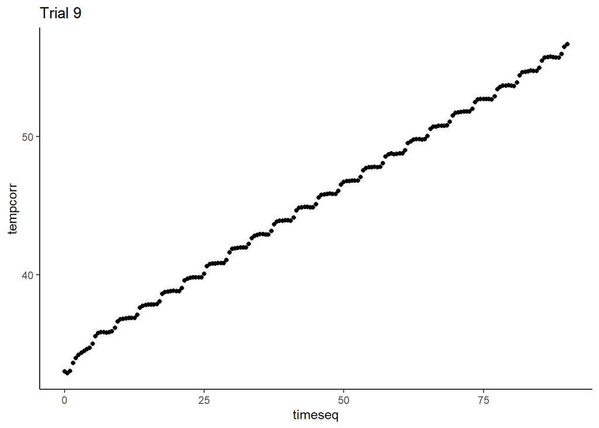

```r
#Trial 9
r9<-all_corr %>%
  filter(trial==9,
         datetime2 >= ymd_hms("2022-06-23 13:08:00") &
                               datetime <= ymd_hms("2022-06-23 14:38:00"))  %>%
  mutate(timeseq=seq(from=0, to=90,by=0.5))

ggplot(r9, aes(x=timeseq, y=tempcorr))+
  geom_point()+theme_classic()+ggtitle("Trial 9")
```

```r
lmtemp<-lm(tempcorr~timeseq, data=r9)
sl9<-lmtemp$coefficients[2]
round(sl9, digits=2)
```

```
## timeseq
##    0.25
```

```r
sl9
```

```
##   timeseq
## 0.2509365
```

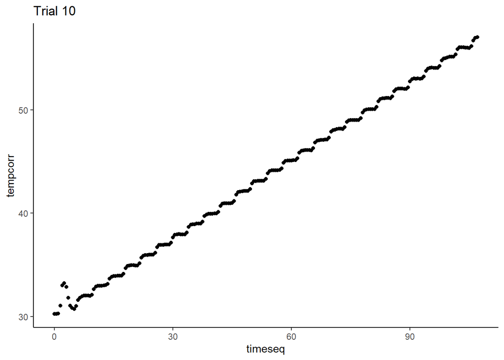

```r
#Trial 10
r10<-all_corr %>%
  filter(trial==10,
         datetime2 >= ymd_hms("2022-06-23 15:50:00") &
                               datetime <= ymd_hms("2022-06-23 17:37:00"))  %>%
  mutate(timeseq=seq(from=0, to=107,by=0.5))

ggplot(r10, aes(x=timeseq, y=tempcorr))+
  geom_point()+theme_classic()+ggtitle("Trial 10")
```

```r
lmtemp<-lm(tempcorr~timeseq, data=r10)
sl10<-lmtemp$coefficients[2]
round(sl10, digits=2)
```

```
## timeseq
##    0.25
```

```r
sl10
```

```
##   timeseq
## 0.2493808
```

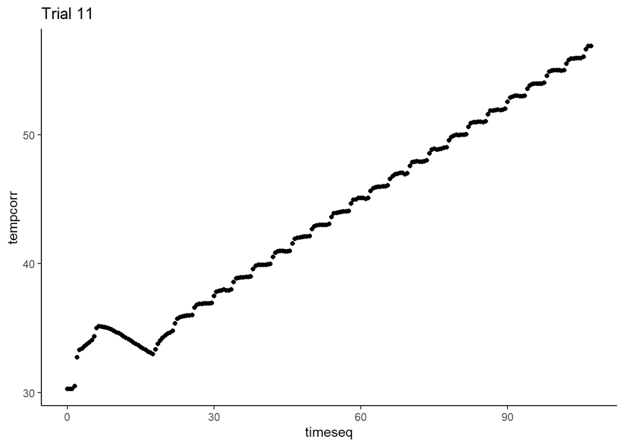

```r
#Trial 11
r11<-all_corr %>%
  filter(trial==11,
         datetime2 >= ymd_hms("2022-06-23 18:45:00") &
                               datetime <= ymd_hms("2022-06-23 20:32:00"))  %>%
  mutate(timeseq=seq(from=0, to=107,by=0.5))

ggplot(r11, aes(x=timeseq, y=tempcorr))+
  geom_point()+theme_classic()+ggtitle("Trial 11")
```

```r
lmtemp<-lm(tempcorr~timeseq, data=r11)
sl11<-lmtemp$coefficients[2]
round(sl11, digits=2)
```

```
## timeseq
##    0.24
```

```r
sl11
```

```
##   timeseq
## 0.2387028
```

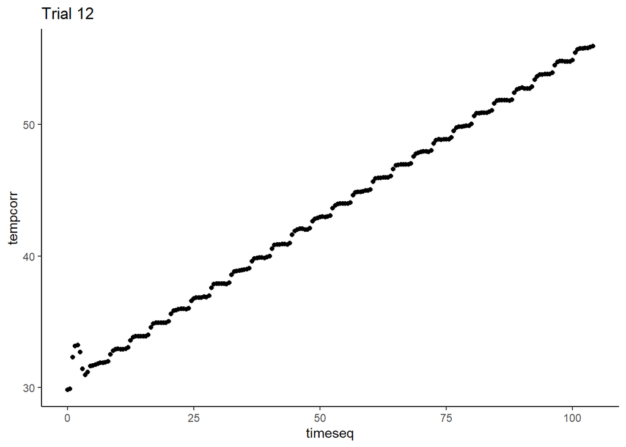

```r
#Trial 12
r12<-all_corr %>%
  filter(trial==12,
         datetime2 >= ymd_hms("2022-06-23 21:57:00") &
                               datetime <= ymd_hms("2022-06-23 23:41:00"))  %>%
  mutate(timeseq=seq(from=0, to=104,by=0.5))

ggplot(r12, aes(x=timeseq, y=tempcorr))+
  geom_point()+theme_classic()+ggtitle("Trial 12")
```

```r
lmtemp<-lm(tempcorr~timeseq, data=r12)
sl12<-lmtemp$coefficients[2]
round(sl12, digits=2)
```

```
## timeseq
##    0.25
```

```r
sl12
```

```
##   timeseq
## 0.2470141
```

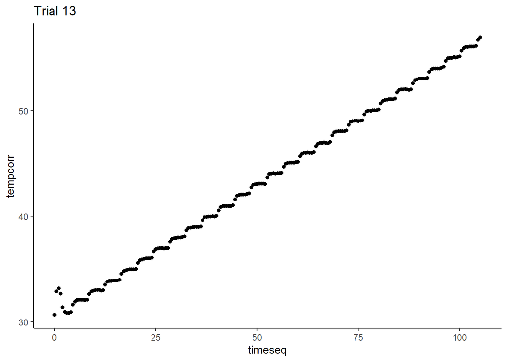

```r
#Trial 13
r13<-all_corr %>%
  filter(trial==13,
         datetime2 >= ymd_hms("2022-06-24 00:58:00") &
                               datetime <= ymd_hms("2022-06-24 02:43:00"))  %>%
  mutate(timeseq=seq(from=0, to=105,by=0.5))

ggplot(r13, aes(x=timeseq, y=tempcorr))+
  geom_point()+theme_classic()+ggtitle("Trial 13")
```

```r
lmtemp<-lm(tempcorr~timeseq, data=r13)
sl13<-lmtemp$coefficients[2]
round(sl13, digits=2)
```

```
## timeseq
##    0.25
```

```r
sl13
```

```
##   timeseq
## 0.2490774
```

```r
slopes<-as.data.frame(c(sl1, sl2, sl3, sl4, sl5,sl6,sl7,sl8,sl9,sl10,sl11,sl12,sl13))
colnames(slopes)<-"uncorr"
```

### 4.4.2 Removing bump at the begining of ramp

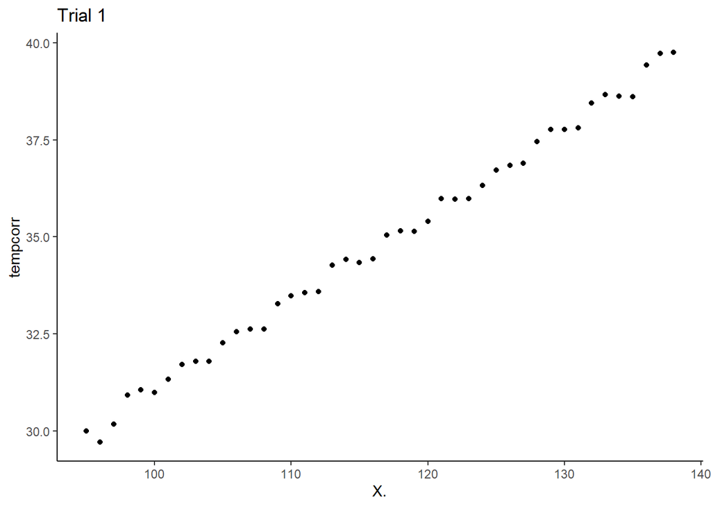

```r
# Trial 1
r1<-all_corr %>%
  filter(trial==1,
         datetime2 >= ymd_hms("2022-06-21 10:07:00") &
                               datetime <= ymd_hms("2022-06-21 10:50:00"))

ggplot(r1, aes(x=X.,y=tempcorr))+
  geom_point()+theme_classic()+ggtitle("Trial 1")
```

```r
lmtemp<-lm(tempcorr~X., data=r1)
sl1<-lmtemp$coefficients[2]
round(sl1, digits=2)
```

```
##   X.
## 0.23
```

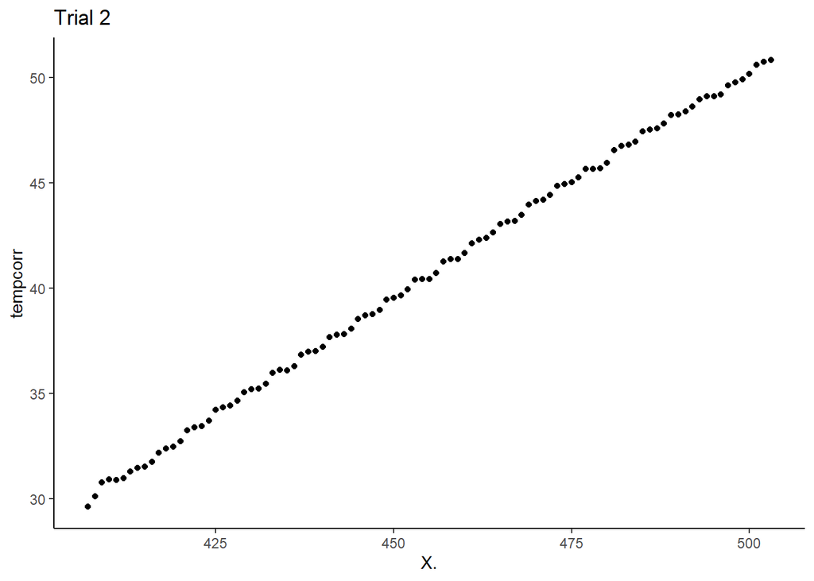

```r
# Trial 2
r2<-all_corr %>%
  filter(trial==2,
         datetime2 >= ymd_hms("2022-06-21 15:16:00") &
                               datetime <= ymd_hms("2022-06-21 16:52:00"))

ggplot(r2, aes(x=X.,y=tempcorr))+
  geom_point()+theme_classic()+ggtitle("Trial 2")
```

```r
lmtemp<-lm(tempcorr~X., data=r2)
sl2<-lmtemp$coefficients[2]
round(sl2, digits=2) #it remains the same independentaly of removing the curve at the begining of the ramp or not
```

```
##   X.
## 0.22
```

```r
sl2
```

```
##        X.
## 0.2195146
```

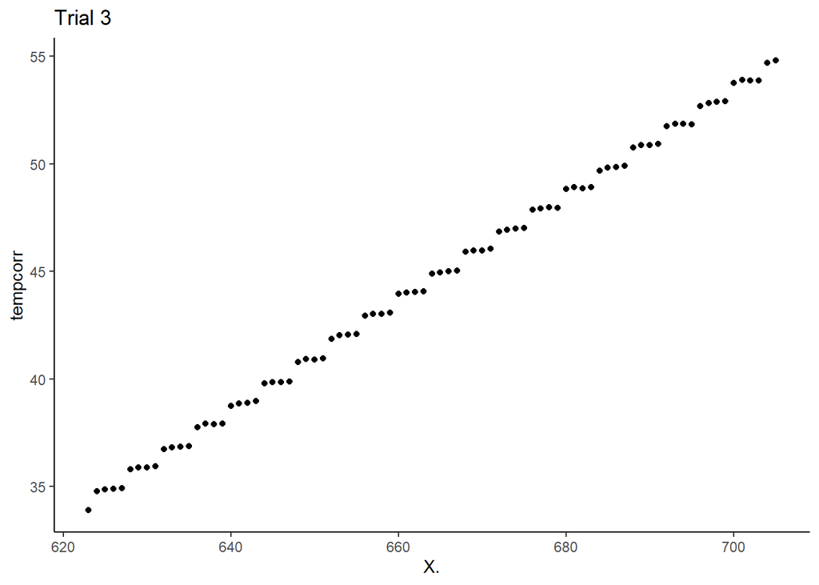

```r
# Trial 3
r3<-all_corr %>%
  filter(trial==3,
         datetime2 >= ymd_hms("2022-06-21 18:49:00") &
                               datetime <= ymd_hms("2022-06-21 20:11:00"))

ggplot(r3, aes(x=X.,y=tempcorr))+
  geom_point()+theme_classic()+ggtitle("Trial 3")
```

```r
lmtemp<-lm(tempcorr~X., data=r3)
sl3<-lmtemp$coefficients[2]
round(sl3, digits=2)
```

```
##   X.
## 0.25
```

```r
sl3
```

```
##        X.
## 0.2499655
```

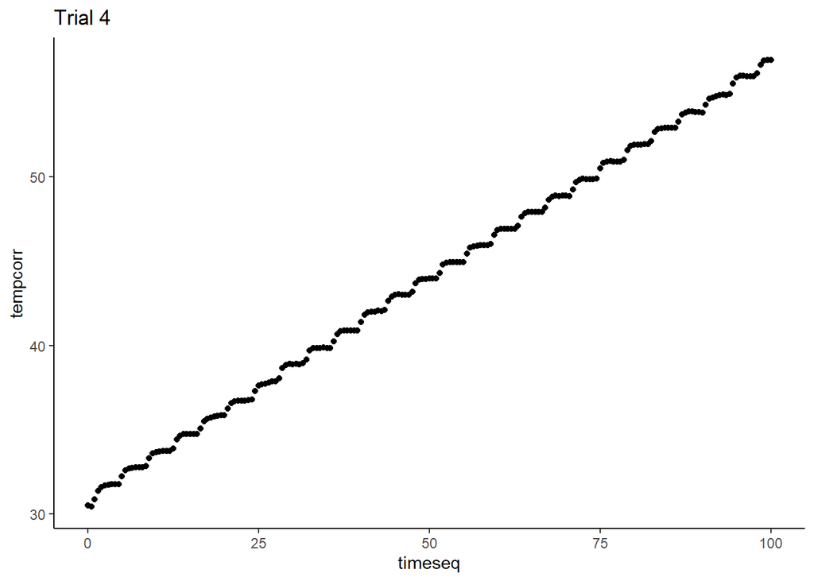

```r
# Trial 4
r4<-all_corr %>%
  filter(trial==4,
         datetime2 >= ymd_hms("2022-06-22 11:22:00") &
                               datetime <= ymd_hms("2022-06-22 13:02:00")) %>%
  mutate(timeseq=seq(from=0, to=100,by=0.5))

ggplot(r4, aes(x=timeseq,y=tempcorr))+
  geom_point()+theme_classic()+ggtitle("Trial 4")
```

```r
lmtemp<-lm(tempcorr~timeseq, data=r4)
sl4<-lmtemp$coefficients[2]
round(sl4, digits=2)
```

```
## timeseq
##    0.26
```

```r
sl4
```

```
##   timeseq
## 0.2595864
```

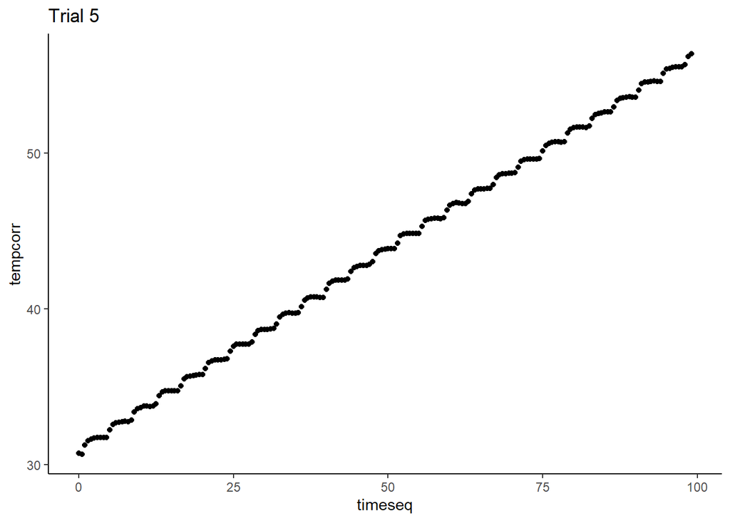

```r
# Trial 5
r5<-all_corr %>%
  filter(trial==5,
         datetime2 >= ymd_hms("2022-06-22 14:27:00") &
                               datetime <= ymd_hms("2022-06-22 16:06:00"))  %>%
  mutate(timeseq=seq(from=0, to=99,by=0.5))

ggplot(r5, aes(x=timeseq,y=tempcorr))+
  geom_point()+theme_classic()+ggtitle("Trial 5")
```

```r
lmtemp<-lm(tempcorr~timeseq, data=r5)
sl5<-lmtemp$coefficients[2]
round(sl5, digits=2)
```

```
## timeseq
##    0.26
```

```r
sl5
```

```
##  timeseq
## 0.255547
```

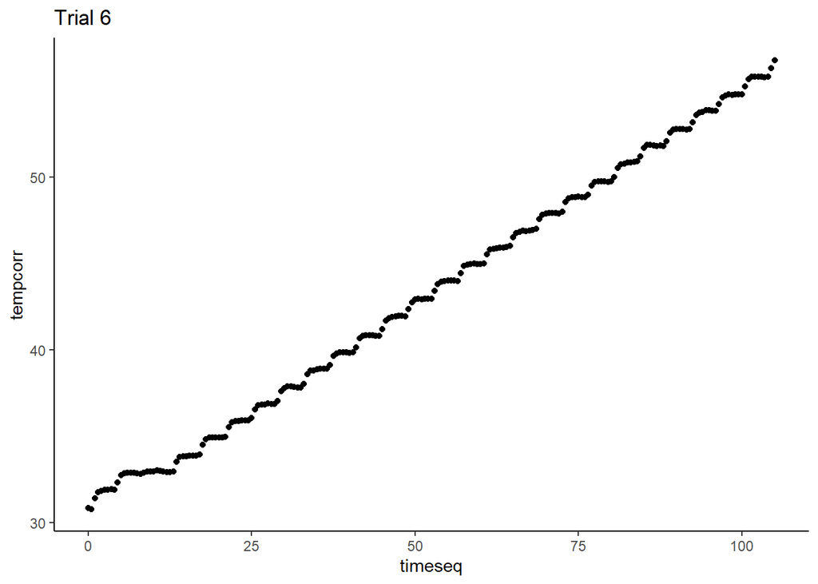

```r
#Trial 6
r6<-all_corr %>%
  filter(trial==6,
         datetime2 >= ymd_hms("2022-06-22 17:47:00") &
                               datetime <= ymd_hms("2022-06-22 19:32:00")) %>%
  mutate(timeseq=seq(from=0, to=105,by=0.5))

ggplot(r6, aes(x=timeseq,y=tempcorr))+
  geom_point()+theme_classic()+ggtitle("Trial 6")
```

```r
lmtemp<-lm(tempcorr~timeseq, data=r6)
sl6<-lmtemp$coefficients[2]
round(sl6, digits=2)
```

```
## timeseq
##    0.25
```

```r
sl6
```

```
##   timeseq
## 0.2460939
```

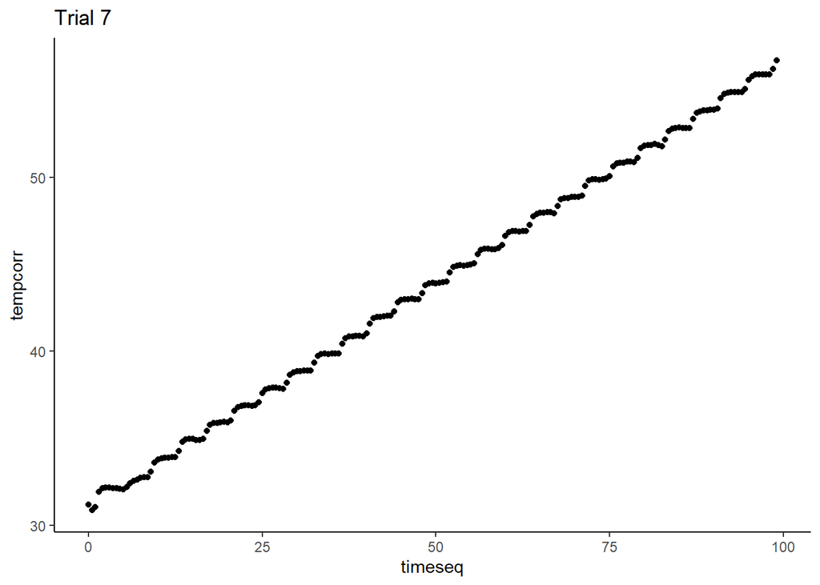

```r
#Trial 7
r7<-all_corr %>%
  filter(trial==7,
         datetime2 >= ymd_hms("2022-06-22 20:40:00") &
                               datetime <= ymd_hms("2022-06-22 22:19:00"))  %>%
  mutate(timeseq=seq(from=0, to=99,by=0.5))

ggplot(r7, aes(x=timeseq,y=tempcorr))+
  geom_point()+theme_classic()+ggtitle("Trial 7")
```

```r
lmtemp<-lm(tempcorr~timeseq, data=r7)
sl7<-lmtemp$coefficients[2]
round(sl7, digits=2)
```

```
## timeseq
##    0.26
```

```r
sl7
```

```
##   timeseq
## 0.2570457
```

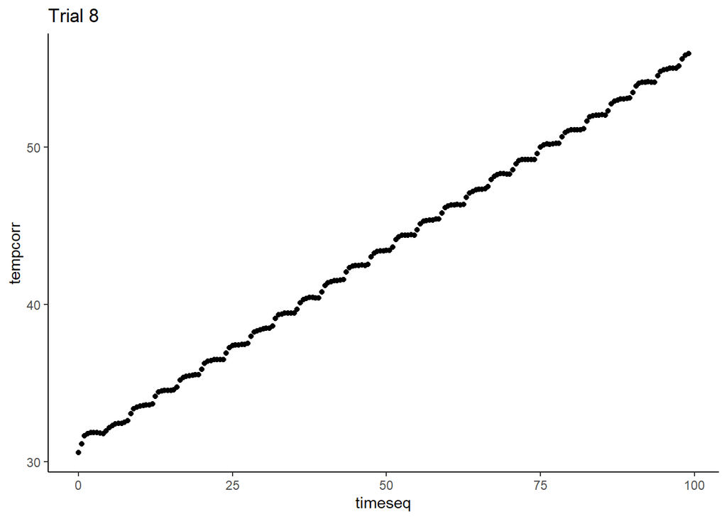

```r
#Trial 8
r8<-all_corr %>%
  filter(trial==8,
         datetime2 >= ymd_hms("2022-06-23 09:52:00") &
                               datetime <= ymd_hms("2022-06-23 11:31:00"))  %>%
  mutate(timeseq=seq(from=0, to=99,by=0.5))

ggplot(r8, aes(x=timeseq, y=tempcorr))+
  geom_point()+theme_classic()+ggtitle("Trial 8")
```

```r
lmtemp<-lm(tempcorr~timeseq, data=r8)
sl8<-lmtemp$coefficients[2]
round(sl8, digits=2)
```

```
## timeseq
##    0.25
```

```r
sl8
```

```
## timeseq
## 0.25092
```

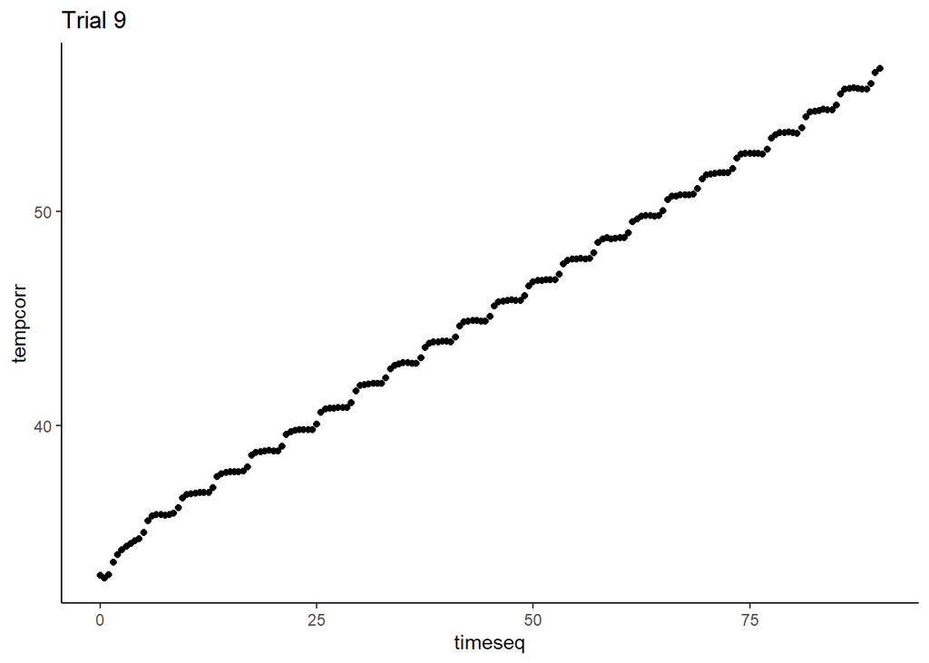

```r
#Trial 9
r9<-all_corr %>%
  filter(trial==9,
         datetime2 >= ymd_hms("2022-06-23 13:08:00") &
                               datetime <= ymd_hms("2022-06-23 14:38:00"))  %>%
  mutate(timeseq=seq(from=0, to=90,by=0.5))

ggplot(r9, aes(x=timeseq, y=tempcorr))+
  geom_point()+theme_classic()+ggtitle("Trial 9")
```

```r
lmtemp<-lm(tempcorr~timeseq, data=r9)
sl9<-lmtemp$coefficients[2]
round(sl9, digits=2)
```

```
## timeseq
##    0.25
```

```r
sl9
```

```
##   timeseq
## 0.2509365
```

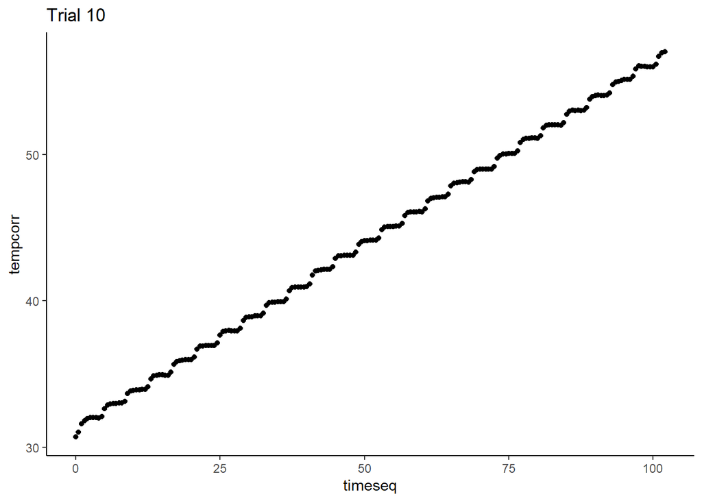

```r
#Trial 10
r10<-all_corr %>%
  filter(trial==10,
         datetime2 >= ymd_hms("2022-06-23 15:55:00") &
                               datetime <= ymd_hms("2022-06-23 17:37:00"))  %>%
  mutate(timeseq=seq(from=0, to=102,by=0.5))

ggplot(r10, aes(x=timeseq, y=tempcorr))+
  geom_point()+theme_classic()+ggtitle("Trial 10")
```

```r
lmtemp<-lm(tempcorr~timeseq, data=r10)
sl10<-lmtemp$coefficients[2]
round(sl10, digits=2)
```

```
## timeseq
##    0.25
```

```r
sl10
```

```
##   timeseq
## 0.2516338
```